# 16-3-2 QA

Emma Wood

14/06/2021

## 16-3-2 update summary

### Introduction

Rundate: 2022-11-11

Data for June of 2009 to June of 2020 have been created and saved as output_2022-11-11.csv in the 16-3-2 Output folder.

There are two sets of data for 2009 as there was a change in methodology in 2010.  
- `2009 see note in original data` is the start of the series from 2009 to 2020.  
- `2009` is the end of the series from 2009.

## Checks

- There are **0** rows with missing values - If greater than 0, check that these are NA in the source data then manually remove these rows from the csv if they are correctly NA.
- If there are multiple numbers for the same selection of disaggregations on the same date, they will show below. Please check which is correct and delete the incorrect one from the csv (for example, in the 2019 amd 2020 datasets, in 2009(a) there are two totals. One is caused by a typo, where the number of people in remand is 13456.02 rather than 13456):

```
## [1] "There are no duplicated rows"
```

## New data compared to live data

Please check the plots and tables below for any differences between the live data (which is pulled in from Github) and the new data.

If there are zig-zag lines or plots look unusual there may be something different in the source data that is causing an issue. This will need to be investigated.

## Differences between live and new data

tiny differences may just be due to differences in rounding, which is not an issue.  
Larger differences may be due to revisions, but could also indicate an error in the code.

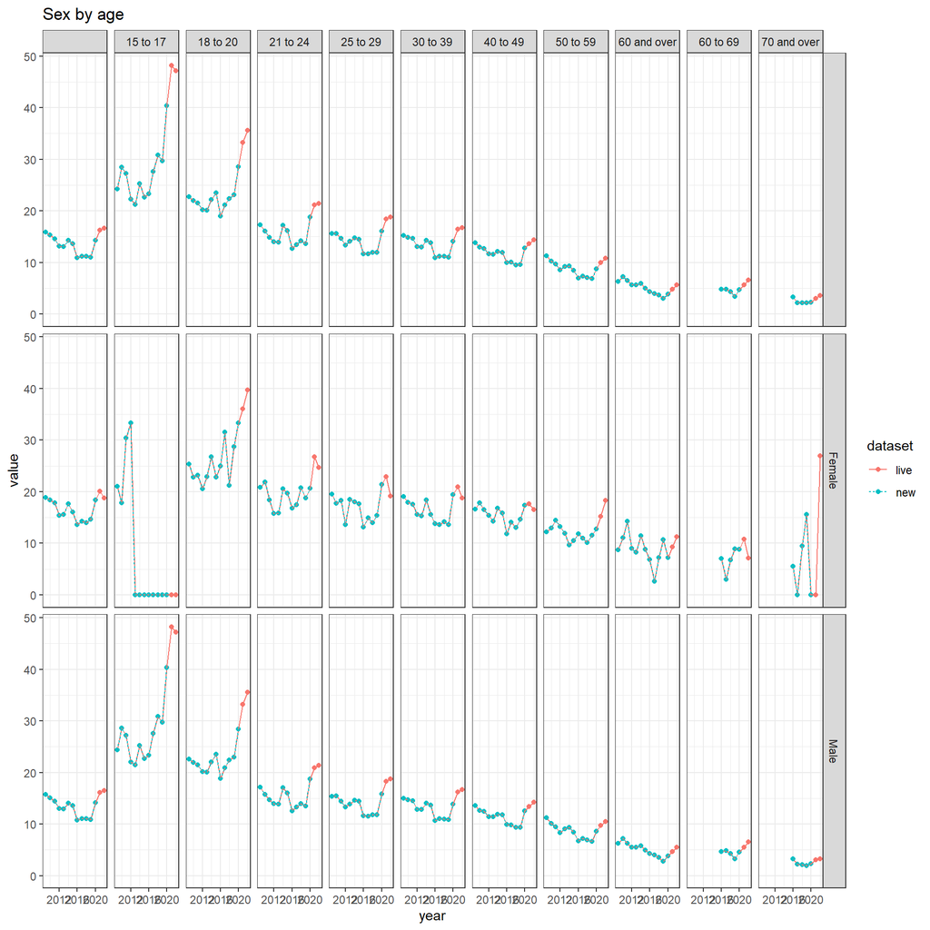

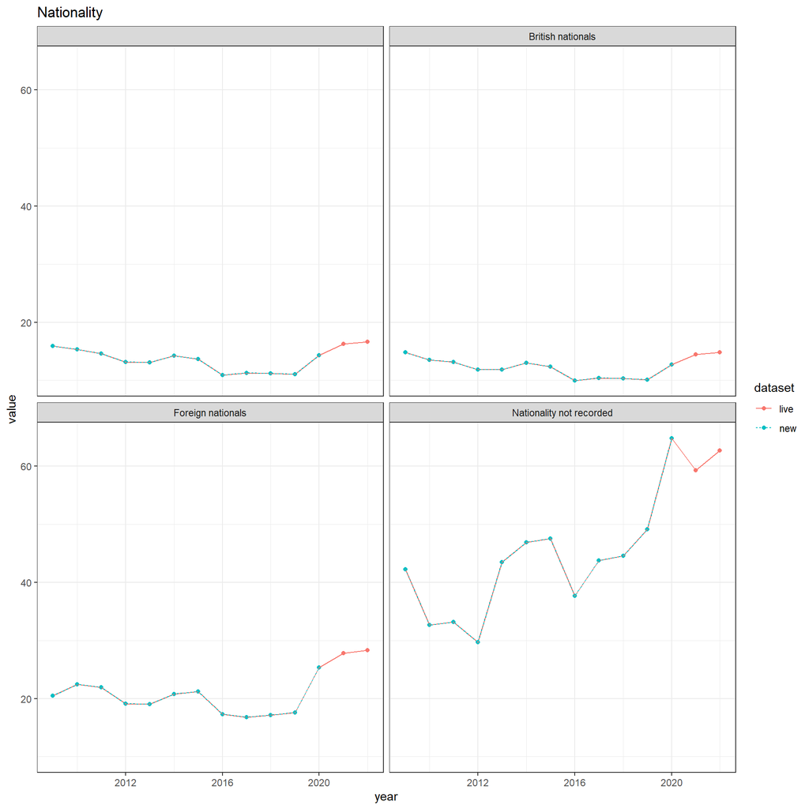

The table below shows all instances where the old value does not match the new value. It is sorted so the largest absolute differences appear first, but can be sorted in other ways using the arrows at the top.

| year | sex | age | nationality | live | new | difference |
| --- | --- | --- | --- | --- | --- | --- |

**R version 4.0.2 (2020-06-22)**

**Platform:** x86_64-w64-mingw32/x64 (64-bit)

**locale:** *LC_COLLATE=English_United Kingdom.1252*, *LC_CTYPE=English_United Kingdom.1252*, *LC_MONETARY=English_United Kingdom.1252*, *LC_NUMERIC=C* and *LC_TIME=English_United Kingdom.1252*

**attached base packages:** *stats*, *graphics*, *grDevices*, *utils*, *datasets*, *methods* and *base*

**other attached packages:** *kableExtra(v.1.3.4)*, *tidyxl(v.1.0.7)*, *unpivotr(v.0.6.2)*, *pander(v.0.6.5)*, *DT(v.0.22)*, *ggplot2(v.3.3.5)*, *janitor(v.2.1.0)*, *openxlsx(v.4.2.5)*, *stringr(v.1.4.0)*, *dplyr(v.1.0.8)*, *tidyr(v.1.2.0)* and *SDGupdater(v.0.0.0.9000)*